# Learning Bayesian modelling with NBA vs EuroLeague data

A guided tour of every model in this project

```r
source(here::here("R", "config.R"))
source(here::here("R", "metrics.R"))
source(here::here("R", "bayes.R"))
source(here::here("R", "data.R"))
source(here::here("R", "theme.R"))
suppressMessages({ library(tidyr); library(ggplot2); library(bayesplot) })
theme_set(theme_project())
tg <- load_team_games(SEASONS_LONG)
```

This notebook is a companion to the analysis scripts. Every section takes one model used in the project, explains it in words, and shows how to check that it does what we think it does. The order goes from simple to more advanced:

| # | Model | Where it is used | New idea |
| --- | --- | --- | --- |
| 1 | Season means around a line | RQ2, replication of the 2019 paper | Hierarchical model, sufficient statistics, centred vs non-centred |
| 2 | Mixed model with team/opponent effects | RQ1, RQ3 | Random effects, priors on a standardised scale, posterior contrasts |
| 3 | Binomial model with logit link | RQ1/RQ3 shot zones | Generalised linear models, overdispersion |
| 4 | Random-walk smooth trend | RQ2 | Latent time series, controlling wiggliness with a prior |
| 5 | Shift model with a discrete lag | RQ2 | Marginalising out a discrete parameter |
| 6 | 2-D spatial smooth | RQ1 accuracy surface | Splines in brms |

The workflow is the same for all of them: **write the model → choose priors → check priors make sense → fit → check the sampler (R-hat, ESS, divergences) → check the fit to data (posterior predictive) → read the posterior.**

# 1. The 2019 paper’s model: season means around a line

## The model

For one league and one variable (say possessions per game), game $i$ in season $j$:

$$y_{ij} \sim \text{Normal}(\mu_j, \sigma_j), \qquad
\mu_j \sim \text{Normal}(\mu + s\,(t_j - 2008),\ \sigma)$$

Two levels: games scatter around their season mean $\mu_j$; season means scatter around a straight line with intercept $\mu$ and slope $s$. This is a *hierarchical* model: the season means are parameters, and they share information through the line.

## Trick 1: sufficient statistics

The NBA has ~2,500 team-games per season. Fitting the game-level model directly (`brms`: `bf(y ~ 1 + t_c + (1 | season), sigma ~ 0 + season)`) took over 10 minutes per fit. But if games within a season are i.i.d. normal, the **count, mean and variance** of each season contain *all* the information about $\mu_j$ and $\sigma_j$:

$$\bar y_j \sim \text{Normal}\!\left(\mu_j, \tfrac{\sigma_j}{\sqrt{n_j}}\right), \qquad
\frac{(n_j-1)\,s_j^2}{\sigma_j^2} \sim \chi^2_{n_j-1}$$

So `RQ2_trends_leadlag/models/paper_trend.stan` takes 3 numbers per season instead of 2,500 and returns the *same* posterior in about a second. Read the Stan file: note the extra `log(n - 1) - 2 * log(sigma_j)` term. That is the Jacobian, needed because we put a density on $s_j^2$ but wrote it as a $\chi^2$ density of a transformed quantity.

## Did it work? Replicating Table 1

```r
rep <- read.csv(here::here("RQ2_trends_leadlag/results/tables/replication_vs_published.csv"))
summarise(rep, max_abs_diff = max(abs(mean - published)), max_rhat = max(max_rhat))
```

```
  max_abs_diff max_rhat
1    0.0128553 1.010669
```

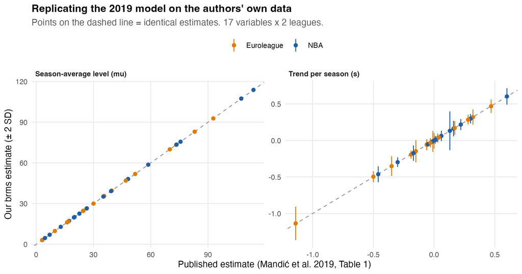

All 68 estimates match the paper to within rounding. **Always validate a model on data where you know the answer before using it on new data.**

## Lesson: centred vs non-centred parameterisation

A few fits first showed *divergent transitions*: the sampler hits a region of very high curvature. This happens when the between-season SD $\sigma$ approaches 0 (the “funnel”). The textbook fix is the **non-centred** form, $\mu_j = \mu + s\,t_j + \sigma z_j$ with $z_j \sim N(0,1)$. We tried it, and it was *worse* (R-hat up to 1.22). Why? Non-centring helps when the data say little about each $\mu_j$. Here every season mean is pinned down by thousands of games, so the centred form is better. We kept the centred form and raised `adapt_delta` to 0.99 (smaller, more careful steps); 16 divergences remained out of 340,000 draws. **The right parameterisation depends on how informative the data are.**

# 2. Mixed models with team and opponent effects (RQ1, RQ3)

## The model

```r
bf(z ~ 0 + league + (1 | team_season) + (1 | opp_season), sigma ~ 0 + league)
```

- `z` is the metric **standardised** (mean 0, SD 1). Then a prior like `normal(0, 1.5)` on the league means is sensible for *every* metric: free throws per foul or minutes entropy alike.
- `(1 | team_season)`: each team-season has its own level, drawn from a normal distribution whose SD is estimated. Games of one team are correlated; ignoring that would make us overconfident.
- `(1 | opp_season)`: the opponent matters too (blocks depend on who you play).
- `sigma ~ 0 + league`: the game-to-game noise may differ by league (distributional regression).

## Prior predictive check

Before fitting, simulate data *from the priors alone* and ask: is this plausible?

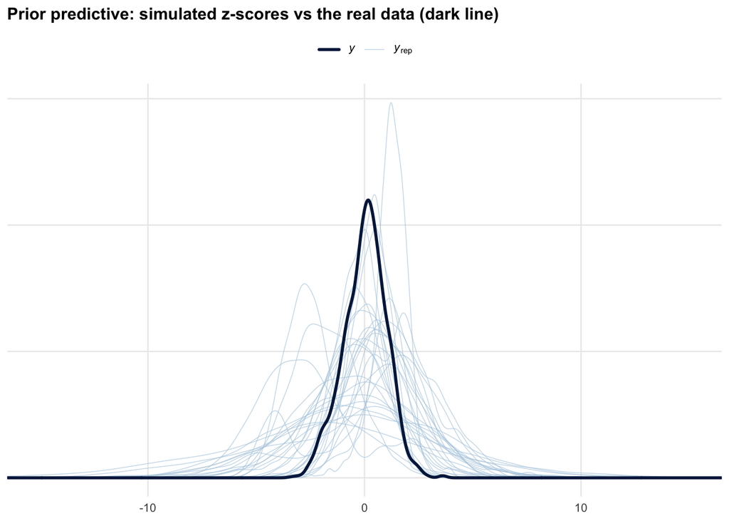

```r
d <- tg |> filter(season %in% TODAY_SEASONS, phase == "regular") |>
  mutate(z = (pace40 - mean(pace40, na.rm = TRUE)) / sd(pace40, na.rm = TRUE)) |>
  filter(is.finite(z)) |> slice_sample(n = 2000)
pp <- brm(bf(z ~ 0 + league + (1 | team_season) + (1 | opp_season), sigma ~ 0 + league),
          data = d, sample_prior = "only", chains = 1, iter = 600, refresh = 0, seed = 1, silent = 2,
          prior = c(prior(normal(0, 1.5), class = "b"), prior(normal(0, 1), class = "sd"),
                    prior(normal(0, 1), class = "b", dpar = "sigma")))
pp_check(pp, ndraws = 30) + coord_cartesian(xlim = c(-15, 15)) +
  labs(title = "Prior predictive: simulated z-scores vs the real data (dark line)")
```

The priors allow a wide range of values, including some silly ones (|z| of 10), but they don’t rule out anything realistic. That is what *weakly informative* means.

## Checking a fitted model

```r
fit <- readRDS(file.path(DATA_ROOT, "RQ1", "models", "box_pace40.rds"))
diagnostics(fit)
```

```
# A tibble: 1 × 4
  max_rhat min_ess_bulk min_ess_tail divergences
     <dbl>        <dbl>        <dbl>       <dbl>
1     1.01         390.         808.           0
```

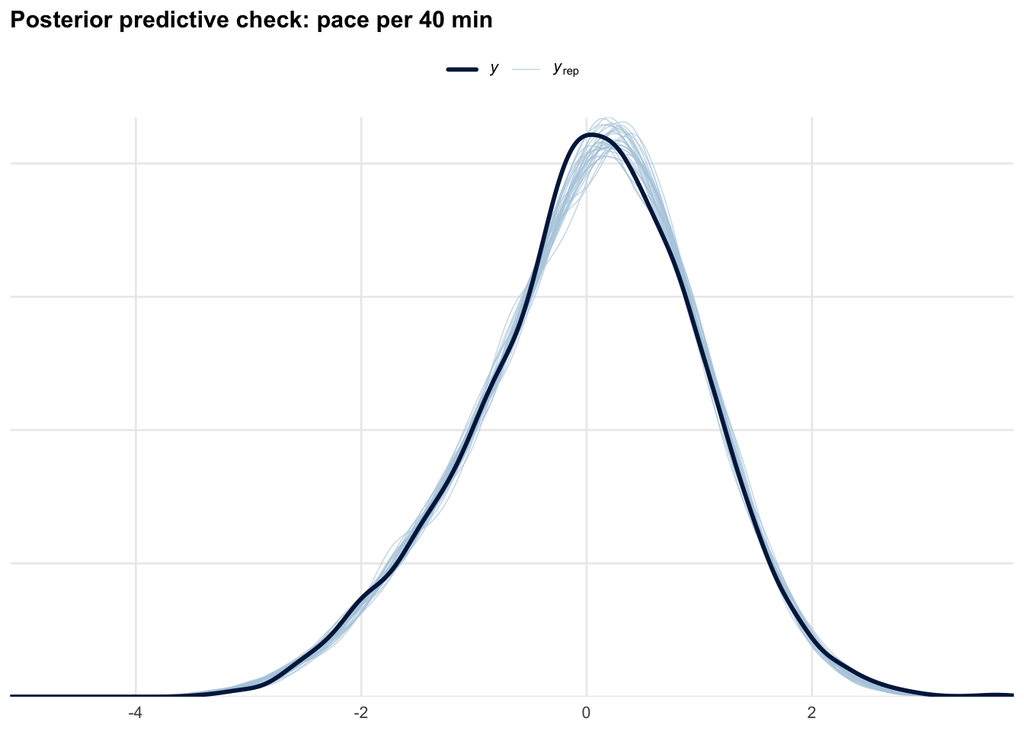

```r
pp_check(fit, ndraws = 30) + labs(title = "Posterior predictive check: pace per 40 min")
```

- **R-hat** ≈ 1.00: the 4 chains agree. Values above 1.01 mean “run longer or fix the model”.
- **ESS** (effective sample size): the number of independent draws the chains are worth. Bulk-ESS above ~400 is enough for means and intervals.
- **Divergences**: should be 0.
- **pp_check**: data simulated from the fitted model should look like the real data.

## Reading the posterior: contrasts

The question “how much faster is the NBA?” is a function of parameters, so we compute it **draw by draw** and summarise at the end:

```r
dr <- as_draws_df(fit)
today <- tg |> filter(season %in% TODAY_SEASONS, phase == "regular", is.finite(pace40))
s <- sd(today$pace40)   # the SD used to standardise; differences only need the scale
diff <- s * (dr$b_leagueNBA - dr$b_leagueEuroLeague)
c(mean = mean(diff), quantile(diff, c(.025, .975)), P_NBA_faster = mean(diff > 0))
```

```
        mean         2.5%        97.5% P_NBA_faster
   10.356951     9.283435    11.395590     1.000000
```

There’s no p-value and no t-test: the posterior of the difference *is* the answer, including statements like “probability the NBA is faster”.

# 3. Binomial models: shot zones

Counts out of totals (corner threes out of all shots; makes out of attempts) are binomial:

```r
bf(n_zone | trials(n_total) ~ 0 + league + (1 | team_season)), family = binomial()
```

The coefficients live on the **logit** scale; `plogis()` turns them into probabilities. The team-season random effect is important: without it the model treats 200,000 NBA shots as independent, and the intervals become absurdly narrow. Real teams differ in style, so the effective sample size is closer to the number of *teams* than of shots.

```r
read.csv(here::here("RQ1_differences_today/results/tables/shot_zones_today.csv")) |>
  select(zone, league, share, share_lo, share_hi, pps) |> mutate(across(where(is.numeric), \(x) round(x, 3)))
```

```
              zone     league share share_lo share_hi   pps
1         Rim area        NBA 0.346    0.339    0.353 1.256
2         Rim area EuroLeague 0.298    0.289    0.307 1.370
3  Short mid-range        NBA 0.163    0.158    0.168 0.877
4  Short mid-range EuroLeague 0.215    0.206    0.224 0.847
5   Long mid-range        NBA 0.076    0.071    0.080 0.825
6   Long mid-range EuroLeague 0.072    0.066    0.077 0.793
7         Corner 3        NBA 0.106    0.101    0.110 1.163
8         Corner 3 EuroLeague 0.045    0.042    0.048 1.275
9    Above-break 3        NBA 0.303    0.296    0.310 1.058
10   Above-break 3 EuroLeague 0.363    0.353    0.373 1.061
```

# 4. Smooth trends: a second-order random walk

The 2019 model forces a straight line. The NBA’s three-point growth is not straight. The RW2 model (`season_curve.stan`) says the trend **keeps its slope** unless the data push it:

$$f_t = 2 f_{t-1} - f_{t-2} + \omega\,\varepsilon_t, \qquad \varepsilon_t \sim N(0,1)$$

$\omega$ controls wiggliness: $\omega=0$ gives a straight line (the 2019 model is a special case), large $\omega$ follows every bump. We put a half-normal(0, 0.3) prior on $\omega$ (on the standardised scale), which prefers smooth curves, and let the data decide.

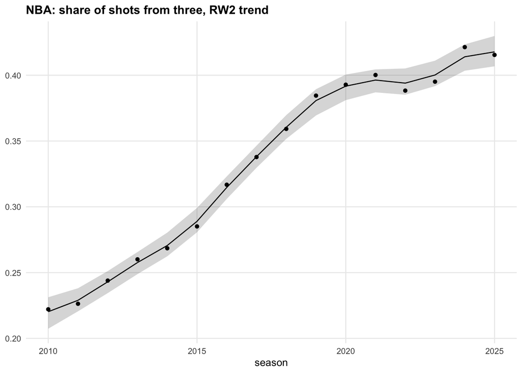

```r
sm <- season_means(tg |> filter(league == "NBA", phase == "regular", season %in% SEASONS), "p3a_share")
f <- fit_season_curve(sm)
tibble(season = sm$season, obs = sm$mean, fit = colMeans(f),
       lo = apply(f, 2, quantile, .025), hi = apply(f, 2, quantile, .975)) |>
  ggplot(aes(season)) + geom_ribbon(aes(ymin = lo, ymax = hi), alpha = .2) +
  geom_line(aes(y = fit)) + geom_point(aes(y = obs)) +
  labs(title = "NBA: share of shots from three, RW2 trend", y = NULL)
```

**A lesson learned the hard way.** The first version sampled the curve $f$ directly. When $\omega$ is small, all the $f_t$ are tied together. That is the funnel again, and it gave divergences and R-hat up to 1.3 in *both* the centred and the non-centred form. The fix: everything in this model is Gaussian, so $f$ can be **integrated out with pen and paper**. Writing $f = M u$ with $u = (f_1, \text{slope}, \varepsilon_3, \dots)$, the season means are jointly $\text{MultiNormal}(0,\ M D M^\top + R)$, where $D = \text{diag}(4, 1, \omega^2, \dots)$ and $R = \text{diag}(se^2 + \tau^2)$. Stan then only samples $\omega$ and $\tau$ (no funnel left), and draws of $f$ are generated afterwards from the exact Gaussian conditional $f \mid y$. Result: 0 divergences and R-hat ≤ 1.005. **When part of a model is Gaussian, integrating it out is often the best reparameterisation of all.** The lead–lag model (next section) uses the same trick.

A neat consequence: because we have **draws of the whole curve**, any question about it has a posterior. “Did the gap between leagues shrink?” is just `mean(abs(gap_2025) < abs(gap_2010))` over the draws.

# 5. A discrete parameter: the lag between leagues

The shift model (`lead_lag.stan`) asks whether the EuroLeague’s curve is the NBA’s curve shifted by $k$ seasons. $k$ is an integer, and Stan’s sampler (HMC) needs continuous parameters. The solution is to **marginalise**: sum the likelihood over all values of $k$,

$$p(\text{data}) = \sum_{k=-5}^{5} p(k)\, p(\text{data} \mid k),$$

which in Stan is `target += log_sum_exp(lp)`. In `generated quantities` we recover $P(k \mid \text{data})$ with `softmax(lp)`. This is the same trick used for mixture models and change-point models.

```r
read.csv(here::here("RQ2_trends_leadlag/results/tables/lead_lag_summary.csv")) |>
  select(label, k_mode, p_mode, p_el_follows, p_nba_follows) |>
  mutate(across(where(is.numeric), \(x) round(x, 2)))
```

```
                       label k_mode p_mode p_el_follows p_nba_follows
1      Assists per 100 poss.     -5   0.41         0.35          0.60
2       Blocks per 100 poss.      0   0.38         0.43          0.19
3     Defensive rebound rate     -3   0.15         0.24          0.66
4              Effective FG%      0   0.58         0.02          0.40
5        Fouls per 100 poss.     -4   0.21         0.28          0.63
6                        FT%      0   0.46         0.47          0.07
7      FTA per foul received      0   0.56         0.15          0.29
8          FTA per 100 poss.     -4   0.21         0.25          0.56
9  Free-throw rate (FTM/FGA)     -4   0.29         0.14          0.73
10    Offensive rebound rate     -3   0.15         0.22          0.67
11      Points per 100 poss.     -1   0.63         0.01          0.88
12                       2P%      0   0.69         0.16          0.15
13         2PA per 100 poss.      2   0.30         0.82          0.08
14                       3P%     -1   0.32         0.04          0.79
15         3PA per 100 poss.      0   0.50         0.31          0.19
16          3PA share of FGA      1   0.41         0.65          0.07
17    Possessions per 40 min      5   0.11         0.45          0.44
18      Steals per 100 poss.      5   0.87         1.00          0.00
19   Turnovers per 100 poss.     -5   0.44         0.06          0.91
20    Rebounds per 100 poss.     -5   0.35         0.14          0.79
```

**Caution.** With ~25 seasons, a smooth trend can often be shifted a few years either way and still fit. A flat posterior over $k$ is an honest “the data can’t tell”, not a failure.

# 6. A 2-D smooth: accuracy across the court

```r
bf(made | trials(n) ~ league + t2(x_abs, y, by = league, k = 8)), family = binomial()
```

`t2()` is a tensor-product spline: a flexible surface over the court. brms turns the spline wiggliness into a random effect (the `sds` parameters), so the amount of smoothing is *estimated*, not chosen by hand. We count shots on a 0.5 m grid first: the binomial likelihood of a cell with 300 shots is exactly the product of 300 Bernoulli likelihoods, but 1,000× faster. This is the same idea as the sufficient statistics in Section 1.

# 7. Shrinkage without MCMC: conjugate priors (RQ4)

RQ4 needs a style profile for about 8,600 player-seasons and team-seasons. A player with 60 shots who took 40% of them from the corner is probably not a corner specialist; he is probably just lucky. **Shrinkage** pulls small samples towards the average, and pulls large samples hardly at all.

Some prior-likelihood pairs give a posterior in the *same family* as the prior: they are **conjugate**, and the posterior can be written down directly, with no sampling algorithm:

| data | prior | posterior |
| --- | --- | --- |
| zone counts $n_1..n_5$ ~ Multinomial($p$) | $p$ ~ Dirichlet($\alpha m$) | Dirichlet($\alpha m + n$) |
| assists $y$ ~ Poisson($\lambda E$), $E$ = possessions | $\lambda$ ~ Gamma($\kappa$, $\kappa/\mu$) | Gamma($\kappa + y$, $\kappa/\mu + E$) |

Read the Dirichlet posterior as **“the prior is worth $\alpha$ imaginary shots”** taken with the league’s average shot mix $m$. With $\alpha = 100$, a player with 60 real shots would end up closer to the league average than to his own numbers; with 1,000 shots his own numbers would dominate. In practice the data choose small values (7–26 shots, below): players at the same position really do take very different shots, so the prior is weak and only small samples are pulled noticeably.

**Who chooses $\alpha$?** The data do. Across all players, the *marginal* likelihood of the counts (the Dirichlet-multinomial, i.e. the likelihood with $p$ integrated out) depends only on $\alpha$. Maximising it is **empirical Bayes**. It is the same “integrate out, then fit” idea as Section 4, and it is what a full hierarchical model would do, but with $\alpha$ fixed at its best value rather than given its own prior.

```r
read.csv(here::here("RQ4_ahead_of_their_time/results/tables/player_prior_strength.csv")) |>
  mutate(across(where(is.numeric), \(x) round(x)))
```

```
      league position dirichlet_alpha ast tov orb drb blk stl pf ftr
1        NBA        C               7   4  12   9  19   5   9 18   6
2        NBA        F               9   5   9   4  13   3  11 13   6
3        NBA        G              17   4   8   5  16   3  12 19   6
4 EuroLeague        C               7   6  13  13  30   3  13 14   7
5 EuroLeague        F              15   6  11   5  15   2  15 16   5
6 EuroLeague        G              26   5  10   5  17   1  10 17   6
```

`dirichlet_alpha` is the prior’s weight in shots, per league and position. The other columns are $\kappa$ for each rate. Because posteriors are closed-form, `R/style.R` draws 300–400 samples per player in a fraction of a second. Each draw is pushed through the rest of the analysis (distances, time positions), so every RQ4 number has a credible interval. “P(most typical)” is simply the share of draws in which a player is the closest to the league average.

**What we gave up.** Empirical Bayes treats $\alpha$ and $\kappa$ as known, so intervals are a little too narrow. With hundreds of players per league that error is small; with ten it would not be.

# Further reading

- McElreath, *Statistical Rethinking* (2nd ed.): the best introduction; chapters 9 (MCMC), 13 (multilevel models), 14 (adventures in covariance).
- Gelman et al. (2020), *Bayesian Workflow*, arXiv:2011.01808: the check-fit-check loop.
- Stan User’s Guide: “Reparameterization” (centred vs non-centred) and “Latent discrete parameters” (marginalisation).
- Bürkner, brms vignettes: `vignette("brms_distreg")` (modelling sigma), `vignette("brms_multilevel")`.